# Predicting recall RT with 2-AFC RT (v4.0)

### March 4 update

- Add 29 more participants
- Add simulated pairings analysis

### Exclusions

```r
trials = all_trials %>% group_by(wid) %>% filter(mean(correct) > 0.25)
n_exclude = length(unique(all_trials$wid)) - length(unique(trials$wid))
N = length(unique(trials$wid))

nt = nrow(trials)
max_rt = with(trials, mean(rt, na.rm=TRUE) + 5 * sd(rt, na.rm=TRUE))
# trials = filter(trials, rt < max_rt)
n_trial = nrow(trials)
n_drop_rt = nt - n_trial

trials %<>% mutate(
    log_afc_rt = log(afc_rt),
    recall_rt = rt,
    log_recall_rt = log(rt)
)
```

## Goal

In the critical phase of our study, we will show participants two images and ask them to enter the word associated with one of them (a “multi-cue recall” task). The primary model prediction is that people will spend more time looking at (trying to remember) the image for which partial recall progresses more quickly.

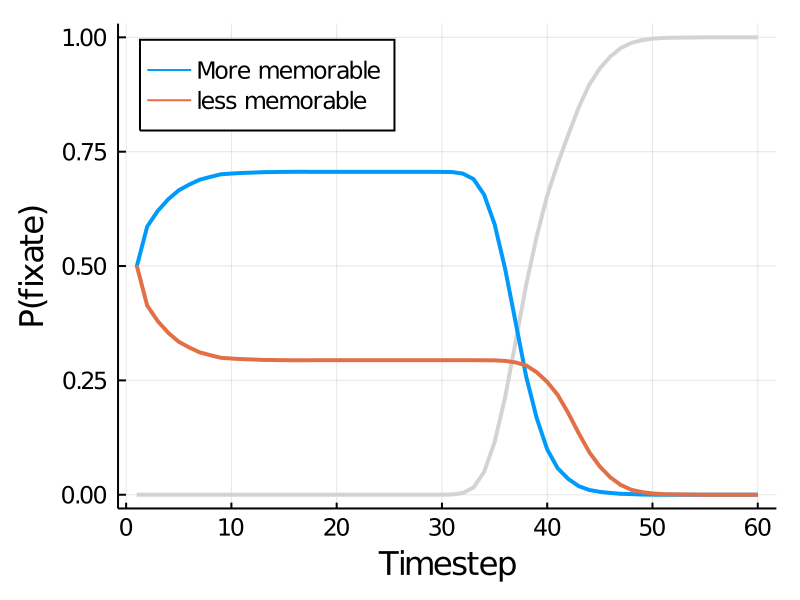

```r
knitr::include_graphics("../model/figs/fixation_by_strength.png")
```

In this experiment, we wanted to verify that this approach might work by asking whether reaction time in the 2-AFC task reliably predicts reaction time in a single cue recall task.

## Does 2-AFC RT predict cue-recall RT?

Is the reaction time on 2AFC trials for a given word predictive of reaction time for the same word in the recall task? Critically, we need to see the effect within individuals, so we plot linear fits for each participant and run a mixed effects model with random intercepts.

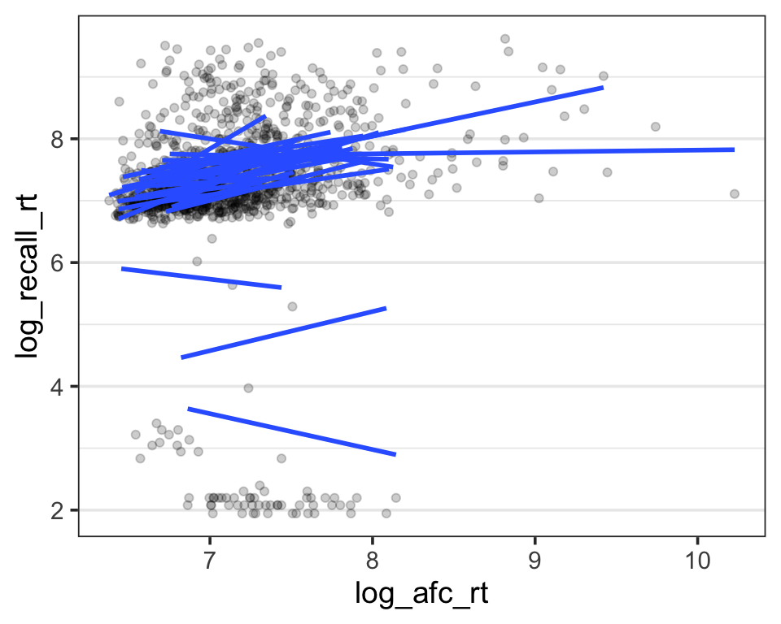

```r
ggplot(trials, aes(log_afc_rt, log_recall_rt, group=wid)) +
    geom_point(alpha=0.2) +
    geom_smooth(method=lm, se=F)
```

```r
trials %>% with(lmer(log_recall_rt ~ log_afc_rt + (1|wid))) %>% summ
```

| Fixed Effects | Fixed Effects Est. | Fixed Effects S.E. | Fixed Effects t val. | Fixed Effects d.f. | Fixed Effects p |
| --- | --- | --- | --- | --- | --- |
| (Intercept) | 4.777 | 0.653 | 7.313 | 921.006 | 0.000 |
| log_afc_rt | 0.338 | 0.088 | 3.838 | 1143.448 | 0.000 |

p values calculated using Satterthwaite d.f.

Looks like we have a consistent effect and reasonably sized effect! We can visualize the individual effects more clearly by clearly by applying participant-wise mean centering:

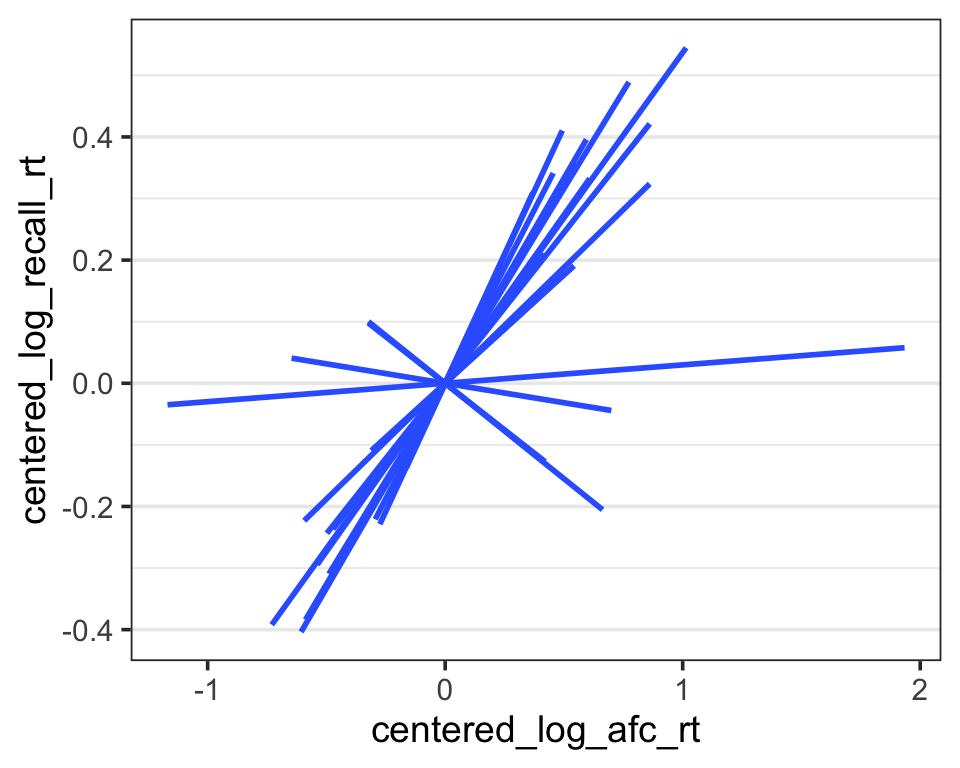

```r
trials %<>% group_by(wid) %>% mutate(
    centered_log_recall_rt = log_recall_rt - mean(log_recall_rt),
    centered_log_afc_rt = log_afc_rt - mean(log_afc_rt),
) %>% ungroup()

ggplot(trials, aes(centered_log_afc_rt, centered_log_recall_rt, group=wid)) +
    geom_smooth(method=lm, se=F)
```

And here is the distribution of slopes (with 95% confidence intervals) and correlations for each participant.

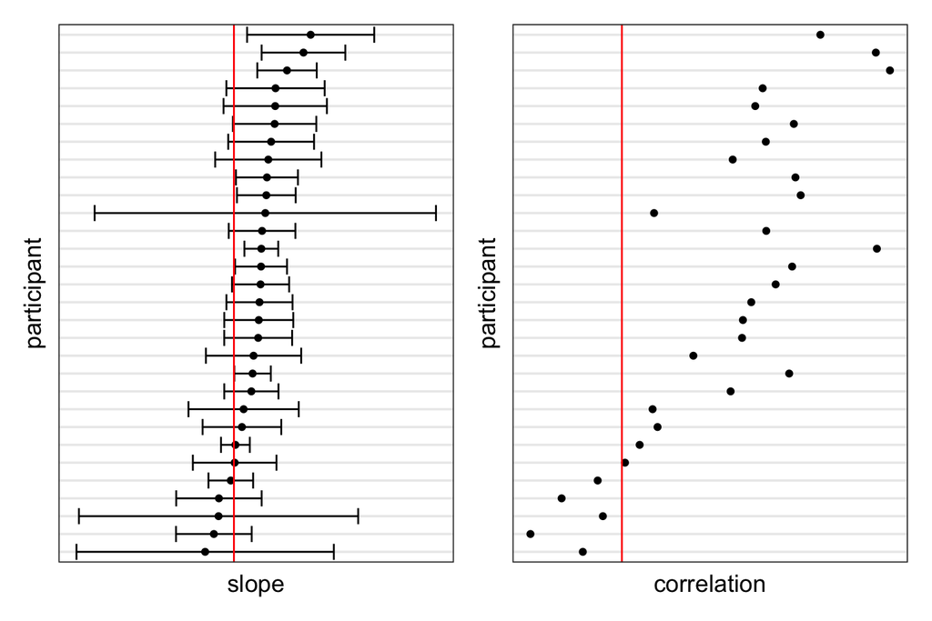

```r
effects = trials %>%
    nest(-wid) %>%
    mutate(
        fit = map(data, ~
            lm(log_recall_rt ~ log_afc_rt, data=.) %>%
            tidy(conf.int = T)
        )
    ) %>%
    unnest(fit) %>%
    filter(term == 'log_afc_rt') %>%
    arrange(estimate)

notick = theme(
  axis.text.x = element_blank(),
  axis.text.y = element_blank(),
  axis.ticks = element_blank())

corrs = trials %>%
    group_by(wid) %>%
    summarise(cor=cor(log_recall_rt, log_afc_rt, use="complete"))

effects = left_join(effects, corrs)

p1 = ggplot(effects, aes(reorder(wid, estimate), estimate)) +
    geom_point() +
    geom_errorbar(aes(ymin=conf.low , ymax=conf.high)) +
    geom_hline(yintercept=0, color="red") +
    labs(y="slope", x="participant") +
    coord_flip() + notick


p2 = ggplot(effects, aes(reorder(wid, estimate), cor)) +
        geom_point() +
        geom_hline(yintercept=0, color="red") +
        labs(y="correlation", x="participant") +
        coord_flip() + notick

prop_slope_positive = with(effects, mean(estimate > 0))

p1 | p2
```

83% of participants have a positive slope.

## Simulated pairings

Another way to analyze this data is to look at what the RT differences would have been if we had paired the items as we plan to do in the critical experiment: slowest with fastest, second slowest with second fastest, and so on. After much exploration, we found that we get the best results when we ignore the AFC accuracy and throw out the first round (leaving just two RT measurements per word).

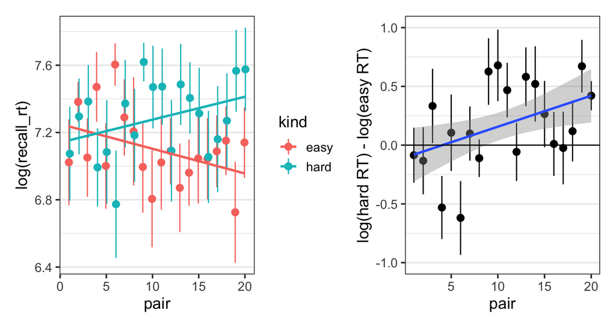

```r
n_pair = 20

make_pairs = function(filt, score) {
    afc %>%
        filter({{ filt }}) %>%
        mutate(score={{ score }}) %>%
        group_by(wid, word) %>%
        summarise(score=mean(score)) %>%
        group_by(wid) %>%
        mutate(score  = score - median(score)) %>%
        arrange(score, .by_group=T) %>%
        mutate(kind=rep(c('easy', 'hard'), each=n_pair), pair=c(n_pair:1, 1:n_pair)) %>%
        left_join(select(trials, wid, word, recall_rt=rt))
}

make_diff = function(pairs) {
    pairs %>%
        pivot_wider(c(wid, pair), values_from=recall_rt, names_from=kind) %>%
        mutate(diff = log(hard) - log(easy), raw_diff = hard - easy)
}

plot_diff = function(dif) {
    ggplot(dif, aes(pair, diff)) +
    stat_summary() +
    labs(y="log(hard RT) - log(easy RT)") +
    geom_smooth(method='lm') +
    coord_cartesian(ylim=c(-1, 1)) +
    geom_hline(yintercept=0)
}


pairs = make_pairs(round > 1, log(rt))
p1 = ggplot(pairs, aes(pair, log(recall_rt), color=kind)) +
    stat_summary(position=position_dodge2(.2)) +
    geom_smooth(method='lm', se=F)

dif = make_diff(pairs)
p2 = plot_diff(dif)

p1 | p2
```

```r
dif %>% with(lm(diff ~ pair)) %>% summ(scale=TRUE)
```

|  | Est. | S.E. | t val. | p |
| --- | --- | --- | --- | --- |
| (Intercept) | 0.171 | 0.060 | 2.833 | 0.005 |
| pair | 0.152 | 0.060 | 2.515 | 0.012 |

Standard errors: OLS; Continuous predictors are mean-centered and scaled by 1 s.d.

### Other scoring approaches

```r
try_strategy = function(filt, score) {
    d = make_pairs({{filt}}, {{score}}) %>% make_diff
    print(d %>% plot_diff)
    d %>% lm(diff ~ pair, data=.) %>% summ(scale=TRUE)
}
```

#### Exclude first round, sort by log(rt).

The chosen way (same as above but replicated for easier comparison).

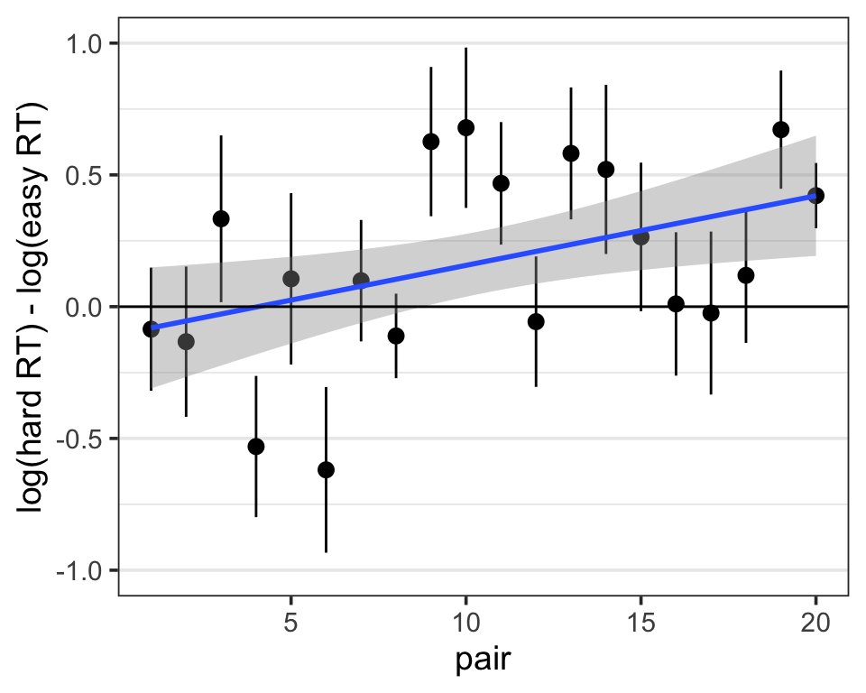

|  | Est. | S.E. | t val. | p |
| --- | --- | --- | --- | --- |
| (Intercept) | 0.171 | 0.060 | 2.833 | 0.005 |
| pair | 0.152 | 0.060 | 2.515 | 0.012 |

```r
try_strategy(round > 1, log(rt)) # plot
```

Standard errors: OLS; Continuous predictors are mean-centered and scaled by 1 s.d.

#### Use raw (non-log) rt.

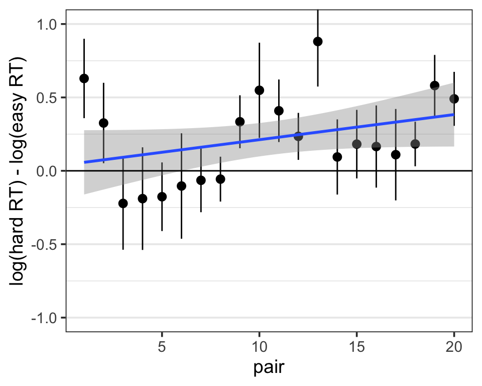

|  | Est. | S.E. | t val. | p |
| --- | --- | --- | --- | --- |
| (Intercept) | 0.221 | 0.058 | 3.836 | 0.000 |
| pair | 0.099 | 0.058 | 1.711 | 0.088 |

```r
try_strategy(round > 1, rt) # plot
```

Standard errors: OLS; Continuous predictors are mean-centered and scaled by 1 s.d.

#### Don’t exclude first round.

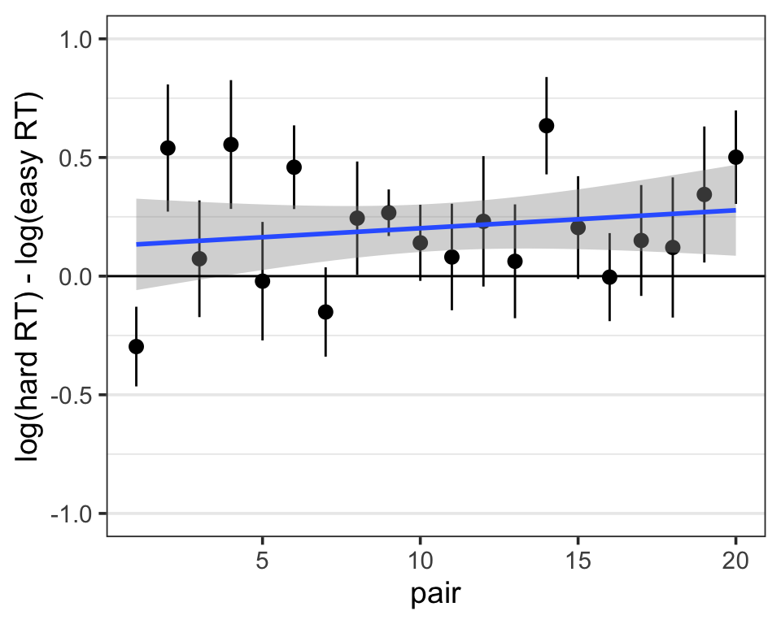

|  | Est. | S.E. | t val. | p |
| --- | --- | --- | --- | --- |
| (Intercept) | 0.206 | 0.051 | 4.057 | 0.000 |
| pair | 0.044 | 0.051 | 0.859 | 0.390 |

```r
# No exclusion
try_strategy(TRUE, log(rt)) # plot
```

Standard errors: OLS; Continuous predictors are mean-centered and scaled by 1 s.d.

#### Sort by accuracy, then log(rt).

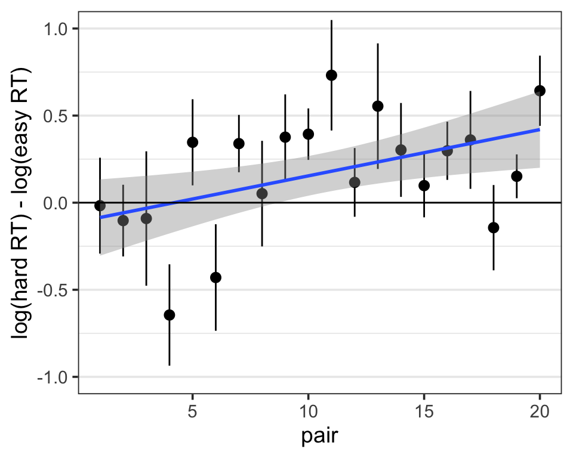

|  | Est. | S.E. | t val. | p |
| --- | --- | --- | --- | --- |
| (Intercept) | 0.167 | 0.058 | 2.889 | 0.004 |
| pair | 0.153 | 0.058 | 2.645 | 0.008 |

```r
try_strategy(round > 1, 1000*(1-correct) + log(rt)) # plot
```

Standard errors: OLS; Continuous predictors are mean-centered and scaled by 1 s.d.

## Check response coding

### Responses classified as “other” (incorrect but not intrusion)

```r
trials %>% filter(word == response)  %>% with(all(correct)) %>% stopifnot
trials %>% filter(response_type == "other") %>% select(word, response) %>% kable
```

| word | response |
| --- | --- |
| stable | staple |
| handkerchief | staple |
| cookie | cookies |
| pizza | sdf |
| enemy | villian |
| villain | villian |
| crook | balsjgdfiqrwg |
| barracuda | sdf |
| application | applicant |
| seagull | seagal |
| society | sociality |
| magazine | newspaper |
| tread | step |
| grizzly | cute |
| major | large |
| seagull | squid |
| jeans | pants |
| major | master |
| follower | escpe |
| stable | keep |
| mister | moustache |
| chimney | chimmy |
| cactus | catucus |
| quill | gull |
| cauliflower | w |
| grizzly | i |
| vagrant | e |
| tart | a |
| major | general |
| ear | bus |

[output cut: 51 more lines]

### Non-exact matches classified as correct

```r
trials %>% filter(correct & word != response) %>% select(word, response) %>% kable
```

| word | response |
| --- | --- |
| jeans | jean |
| barracuda | baracuda |
| volunteer | volontuer |
| barracuda | baracuda |
| bed | bed´ |
| hamburger | hamburguer |
| gravel | graval |
| scapegoat | escapegoat |
| seagull | seaguill |
| lover | lovers |
| saxophone | saxaphone |
| saxophone | saxaphone |
| tractor | tracotr |
| stairs | stair |
| suburb | suburbs |
| goat | goart |
| pitchfork | ptchfork |
| patient | patients |
| grizzly | grizly |
| jeans | jean |
| personnel | pesonnel |
| walrus | walrose |